# Mini Project 3

Author

Ian Peralta, Ashley Song, Bryan Xiao

This file combines the response variable, population in 2020, with the 10 predictors for Mini Project 3. Eight predictors are quantitative and two are categorical, income level and democracy. Missing values are kept for now.

## Libraries

```r
library(tidyverse)
library(ggplot2)
library(parsnip)
library(rsample)
library(recipes)
library(workflows)
library(tune)
library(dials)
library(yardstick)
library(broom)
library(glmnet)
library(rpart)
library(rpart.plot)
library(ranger)
```

## Loading Data

```r
# Predictors from Mini Projects 1 and 2
children   <- read_csv("../data/predictors/children_per_woman_total_fertility.csv")
income     <- read_csv("../data/predictors/ilevels4_wb.csv", col_types = cols(.default = "c"))
sanitation <- read_csv("../data/predictors/at_least_basic_sanitation_overall_access_percent.csv")
poverty    <- read_csv("../data/predictors/number_of_people_in_poverty.csv")
democracy  <- read_csv("../data/predictors/democracy2020.csv")

# New predictors
employment <- read_csv("../data/predictors/aged_15plus_employment_rate_percent.csv")
energy     <- read_csv("../data/predictors/energy_use_per_person.csv")
inflation  <- read_csv("../data/predictors/inflation_annual_percent.csv")
lifeexp    <- read_csv("../data/predictors/lex.csv")
murder     <- read_csv("../data/predictors/murder_total_deaths.csv")

# Response
population <- read_csv("../data/response/pop.csv")
```

## Cleaning Data

Each file has one column per year. The function below drops the years after 2022 and pivots to one row per country and year. Democracy only has 2020 so it gets a year column added instead.

```r
drop_and_pivot <- function(df, value_name) {
  df |>
    select(-any_of(as.character(2023:2100))) |>
    pivot_longer(
      cols = -c(geo, name),
      names_to = "year",
      values_to = value_name
    ) |>
    mutate(year = as.integer(year))
}

pop_long        <- drop_and_pivot(population, "population")
children_long   <- drop_and_pivot(children, "children_per_woman")
income_long     <- drop_and_pivot(income, "income_level")
sanitation_long <- drop_and_pivot(sanitation, "sanitation_access_pct")
poverty_long    <- drop_and_pivot(poverty, "people_in_poverty")
employment_long <- drop_and_pivot(employment, "employment_rate_pct")
energy_long     <- drop_and_pivot(energy, "energy_use_per_person")
inflation_long  <- drop_and_pivot(inflation, "inflation_pct")
lifeexp_long    <- drop_and_pivot(lifeexp, "life_expectancy")
murder_long     <- drop_and_pivot(murder, "murder_deaths")

democracy_long  <- democracy |>
  mutate(year = 2020L) |>
  select(geo, year, Democracy)
```

## Joining Data

Population is the response so every predictor is joined onto it by country and year, then the data is filtered to 2020. This keeps every country in the population file and leaves NA wherever a predictor is missing, so nothing gets dropped yet.

```r
predictors_long <- list(
  children_long, income_long, sanitation_long, poverty_long,
  employment_long, energy_long, inflation_long, lifeexp_long, murder_long
) |>
  map(\(df) select(df, -name))

combined <- reduce(
  c(list(pop_long), predictors_long, list(democracy_long)),
  left_join,
  by = c("geo", "year")
) |>
  filter(year == 2020) |>
  arrange(geo)
```

## Logging Variables

Population, people in poverty, murder deaths and energy use per person are all counts or amounts with a few huge values, so we log them. Inflation is not logged because 48 countries have negative inflation in 2020 and the log of a negative number doesn’t exist. The rest are not strongly skewed.

```r
combined <- combined |>
  mutate(
    log_pop               = log(population),
    log_people_in_poverty = log(people_in_poverty),
    log_murder_deaths     = log(murder_deaths),
    log_energy_use        = log(energy_use_per_person)
  ) |>
  select(-population, -people_in_poverty, -murder_deaths, -energy_use_per_person)
```

## Checking Data

```r
dim(combined)
```

```
[1] 195  14
```

```r
table(combined$Democracy, useNA = "ifany")
```

```
  No  Yes <NA>
  91   74   30
```

```r
# Missing values per column
colSums(is.na(combined))
```

```
                  geo                  name                  year
                    0                     0                     0
   children_per_woman          income_level sanitation_access_pct
                    0                     1                    10
  employment_rate_pct         inflation_pct       life_expectancy
                   16                     6                     1
            Democracy               log_pop log_people_in_poverty
                   30                     1                    10
    log_murder_deaths        log_energy_use
                    2                    49
```

## Writing Data

```r
write_csv(combined, "../data/combined_data.csv")
```

## Exploratory data analysis

We read the combined data back in and use `na.omit()` so every predictor is looked at on the same countries that the models will use later.

```r
combined <- read_csv("../data/combined_data.csv")
combined <- combined |>
  na.omit()
```

For this section graph and find statistics for each of your 5 new predictor variables vs the response. You do not need to look at the predictor variables individually, although you can if you are considering logging.

## Variable 1: Employment

### Graph and description

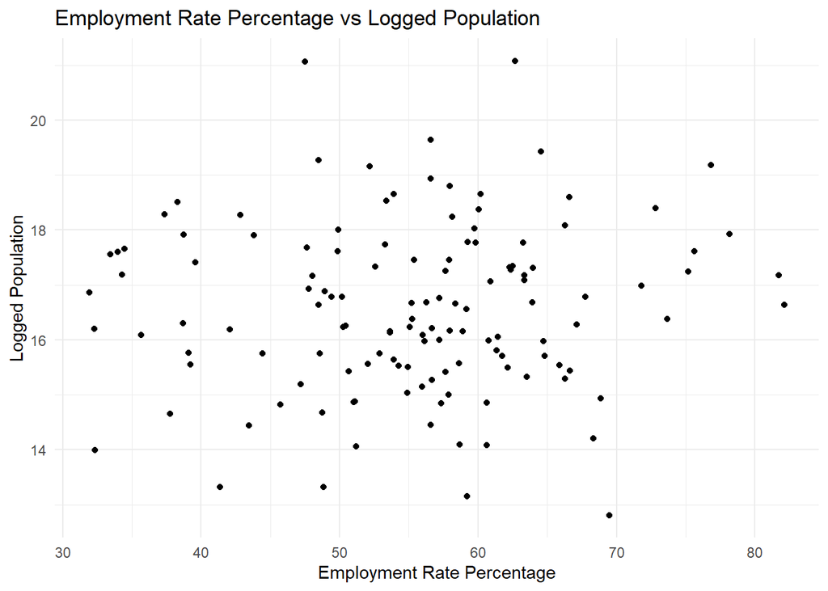

```r
combined |>
  ggplot(mapping = aes(x = employment_rate_pct, y = log_pop)) +
  geom_point() +
  labs(title = "Employment Rate Percentage vs Logged Population",
       x = "Employment Rate Percentage", y = "Logged Population") +
  theme_minimal()
```

There does not seem to be much correlation between the employment rate percentage and population. The graph lacks a semblance of any trend or pattern. From this initial look, employment rate may not be a good predictor variable for population.

### Stats and description

```r
combined |>
  group_by(percent_bins = cut(log_pop, breaks = c(12.5, 15, 17.5, 20, 22.5))) |>
  summarise(
    n_countries = n(),
    mean        = mean(employment_rate_pct),
    median      = median(employment_rate_pct),
    sd          = sd(employment_rate_pct),
    min         = min(employment_rate_pct),
    q1          = quantile(employment_rate_pct, 0.25),
    q3          = quantile(employment_rate_pct, 0.75),
    max         = max(employment_rate_pct),
    .groups     = "drop"
  )
```

```
# A tibble: 4 × 9
  percent_bins n_countries  mean median    sd   min    q1    q3   max
  <fct>              <int> <dbl>  <dbl> <dbl> <dbl> <dbl> <dbl> <dbl>
1 (12.5,15]             19  53.2   51.2  10.4  32.3  47.2  59.9  69.5
2 (15,17.5]             77  56.1   56.7  10.1  31.9  50.4  62.3  82.1
3 (17.5,20]             33  54.7   56.6  12.4  33.4  47.6  60.2  78.2
4 (20,22.5]              2  55.1   55.1  10.7  47.5  51.3  58.9  62.7
```

Employment rates are fairly similar across all population bins with mean ranging between 53% and 56% and median ranging between 51% and 57%. The spread of the data is moderate across all population groups with standard deviations being around 10-12%. The 15 to 17.5 group has the largest number of countries, while the 20 to 22.5 group has the smallest with only 2 countries.

## Variable 2: Energy

### Graph and description

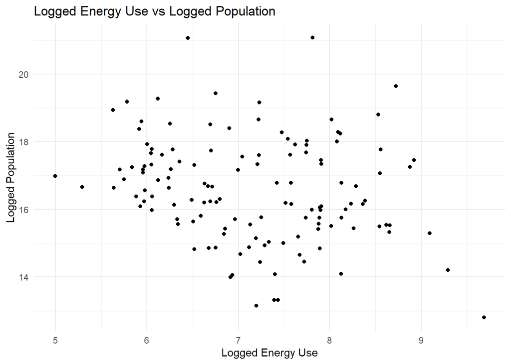

```r
combined |>
  ggplot(mapping = aes(x = log_energy_use, y = log_pop)) +
  geom_point() +
  labs(title = "Logged Energy Use vs Logged Population",
       x = "Logged Energy Use", y = "Logged Population") +
  theme_minimal()
```

There may be a negative correlation between energy use and population. There seems to be a general trend that smaller populations will have higher energy use. With this in mind, energy use may be a good predictor variable for population.

### Stats and description

```r
combined |>
  group_by(percent_bins = cut(log_pop, breaks = c(12.5, 15, 17.5, 20, 22.5, 25))) |>
  summarise(
    n_countries = n(),
    mean        = mean(log_energy_use),
    median      = median(log_energy_use),
    sd          = sd(log_energy_use),
    min         = min(log_energy_use),
    q1          = quantile(log_energy_use, 0.25),
    q3          = quantile(log_energy_use, 0.75),
    max         = max(log_energy_use),
    .groups     = "drop"
  )
```

```
# A tibble: 4 × 9
  percent_bins n_countries  mean median    sd   min    q1    q3   max
  <fct>              <int> <dbl>  <dbl> <dbl> <dbl> <dbl> <dbl> <dbl>
1 (12.5,15]             19  7.49   7.29 0.819  6.52  6.98  7.69  9.69
2 (15,17.5]             77  7.11   7.00 1.00   5.00  6.26  7.91  9.09
3 (17.5,20]             33  7.08   7.22 0.910  5.63  6.16  7.75  8.72
4 (20,22.5]              2  7.13   7.13 0.962  6.45  6.79  7.47  7.81
```

Logged energy use is fairly similar across population bins with means ranging from 7.08 to 7.49 and medians ranging from 7 to 7.29. The 12.5 to 15 population bin has the biggest mean and median, while the 17.5 to 20 bin has the smallest mean and 15 to 17.5 bin has the smallest median. The standard deviation is between 0.82 and 1 across all population bins. The 15 to 17.5 bin has the largest standard deviation, while the 12.5 to 15 population bin has the smallest standard deviation.

## Variable 3: Murder

### Graph and description

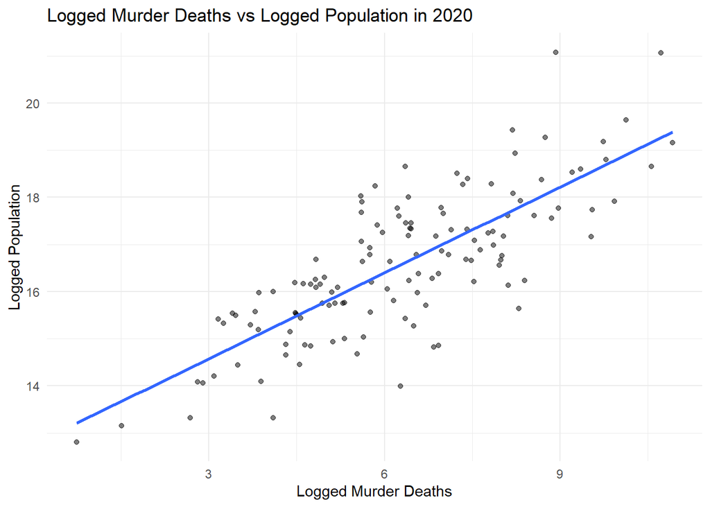

```r
combined |>
  ggplot(mapping = aes(x = log_murder_deaths, y = log_pop)) +
  geom_point(alpha = 0.5) +
  geom_smooth(method = "lm", formula = y ~ x, se = FALSE) +
  labs(title = "Logged Murder Deaths vs Logged Population in 2020",
       x = "Logged Murder Deaths", y = "Logged Population") +
  theme_minimal()
```

Logged murder deaths and logged population go up together in a pretty clear straight line, so countries with more murders tend to have more people, which makes sense since murder deaths is a total count that grows with the size of a country. The points scatter a bit around the line but there’s no curve or strange gap, so murder deaths looks like a good predictor of population.

### Stats and description

```r
combined |>
  group_by(pop_bins = cut(log_pop, breaks = c(12.5, 15, 17.5, 20, 22.5))) |>
  summarise(
    n_countries = n(),
    mean        = mean(log_murder_deaths),
    median      = median(log_murder_deaths),
    sd          = sd(log_murder_deaths),
    min         = min(log_murder_deaths),
    q1          = quantile(log_murder_deaths, 0.25),
    q3          = quantile(log_murder_deaths, 0.75),
    max         = max(log_murder_deaths),
    .groups     = "drop"
  )
```

```
# A tibble: 4 × 9
  pop_bins  n_countries  mean median    sd   min    q1    q3   max
  <fct>           <int> <dbl>  <dbl> <dbl> <dbl> <dbl> <dbl> <dbl>
1 (12.5,15]          19  4.13   4.31  1.65 0.742  2.99  4.93  6.92
2 (15,17.5]          77  5.96   5.97  1.44 3.16   4.83  6.98  9.54
3 (17.5,20]          33  8.05   8.20  1.53 5.60   6.97  9.21 10.9
4 (20,22.5]           2  9.83   9.83  1.27 8.93   9.38 10.3  10.7
```

Murder deaths are skewed and the correlation with population is stronger once we log them, so we check both.

```r
skew <- function(x) mean((x - mean(x))^3) / sd(x)^3

tibble(
  scale       = c("Original", "Logged"),
  skewness    = c(skew(exp(combined$log_murder_deaths)), skew(combined$log_murder_deaths)),
  correlation = c(cor(exp(combined$log_murder_deaths), exp(combined$log_pop)),
                  cor(combined$log_murder_deaths, combined$log_pop))
)
```

```
# A tibble: 2 × 3
  scale    skewness correlation
  <chr>       <dbl>       <dbl>
1 Original   4.43         0.517
2 Logged     0.0247       0.785
```

The outlier lookup uses the fit in the graph, and a standardized residual is how many standard deviations a country sits from the line. We also look at the countries with the most and fewest murders.

```r
murder_fit <- lm(log_pop ~ log_murder_deaths, data = combined)

murder_countries <- combined |>
  mutate(
    population    = exp(log_pop),
    murder_deaths = exp(log_murder_deaths),
    per_100k      = murder_deaths / population * 100000,
    std_residual  = as.numeric(scale(resid(murder_fit)))
  ) |>
  select(name, population, murder_deaths, per_100k, std_residual)

# largest standardized residuals
murder_countries |> slice_max(abs(std_residual), n = 5)
```

```
# A tibble: 5 × 5
  name         population murder_deaths per_100k std_residual
  <chr>             <dbl>         <dbl>    <dbl>        <dbl>
1 China       1426106093.         7536.    0.528         3.07
2 Eswatini       1192729.          530.   44.4          -2.72
3 El Salvador    6234673.         3998.   64.1          -2.26
4 Jamaica        2830739          1016.   35.9          -2.22
5 Namibia        2728762           940.   34.5          -2.21
```

```r
# most and fewest murders
murder_countries |> slice_max(murder_deaths, n = 4)
```

```
# A tibble: 4 × 5
  name    population murder_deaths per_100k std_residual
  <chr>        <dbl>         <dbl>    <dbl>        <dbl>
1 Brazil  208660842.        55080.    26.4        -0.238
2 India  1402617695.        45473.     3.24        1.90
3 Mexico  126799054.        38588.    30.4        -0.536
4 USA     339436159         25003.     7.37        0.782
```

```r
murder_countries |> slice_min(murder_deaths, n = 3)
```

```
# A tibble: 3 × 5
  name       population murder_deaths per_100k std_residual
  <chr>           <dbl>         <dbl>    <dbl>        <dbl>
1 Iceland       366614.          2.1     0.573       -0.417
2 Malta         518207.          4.52    0.872       -0.542
3 Montenegro    607935          14.6     2.40        -1.12
```

The mean of logged murder deaths goes up with every population bin, from 4.13 in the smallest countries to 8.05 in the 17.5 to 20 bin, and the medians do the same thing, going from 4.31 up to 8.20. The top bin is only 2 countries, China and India, so its mean of 9.83 doesn’t tell us much on its own but it keeps the same pattern. The standard deviations stay between 1.27 and 1.65 in every bin, so countries of about the same size can still have quite different numbers of murders.

Murder deaths is very right skewed on the original scale with a skewness of 4.43, and after logging it’s basically symmetric at 0.02. The correlation with population also goes from 0.52 to 0.79, so murder deaths needs to be logged and we already did that in the data step.

China is the only extreme outlier, with a standardized residual of 3.07 since it has about 7,500 murder deaths for 1.43 billion people, which is around 0.5 per 100,000 and way fewer murders than its population predicts. Eswatini, El Salvador, Jamaica and Namibia are on the other side with murder rates between 34 and 64 per 100,000, so they have a lot more murders than other countries of their size. On the original scale the most murders are in Brazil with 55,080, India with 45,473, Mexico with 38,588 and the USA with 25,003, and the fewest are in Iceland with 2.1 and Malta with 4.5. Murder deaths is a total and not a rate, so some of this strong relationship is just population showing up on both sides, but it still makes it a strong predictor for population.

## Variable 4: Inflation

### Graph and description

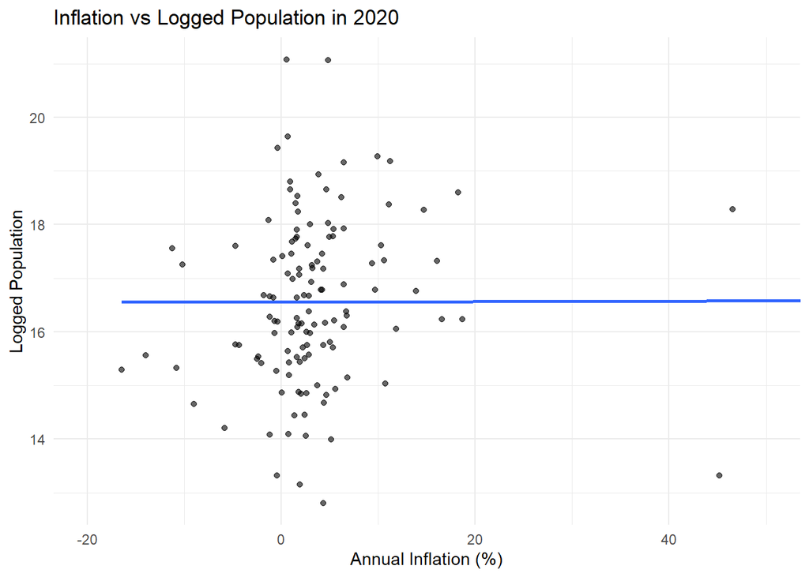

```r
combined |>
  ggplot(mapping = aes(x = inflation_pct, y = log_pop)) +
  geom_point(alpha = 0.6) +
  geom_smooth(method = "lm", formula = y ~ x, se = FALSE) +
  coord_cartesian(xlim = c(-20, 50)) +
  labs(
    title = "Inflation vs Logged Population in 2020",
    x = "Annual Inflation (%)",
    y = "Logged Population"
  ) +
  theme_minimal()
```

Most countries have relatively low inflation rates, while a small number of countries have extremely high inflation rates. A few extreme inflation outliers make the overall relationship difficult to visualize, so we removed the outliers to get a better look at the distribution. There does not appear to be a strong linear relationship between annual inflation and logged population. The points are widely scattered, and the fitted regression line is almost horizontal, suggesting little to no correlation between the two variables.

### Stats and description

```r
combined |>
  group_by(pop_bins = cut_number(log_pop, n = 4)) |>
  summarise(
    n_countries = n(),
    mean        = mean(inflation_pct),
    median      = median(inflation_pct),
    sd          = sd(inflation_pct),
    min         = min(inflation_pct),
    q1          = quantile(inflation_pct, 0.25),
    q3          = quantile(inflation_pct, 0.75),
    max         = max(inflation_pct),
    .groups     = "drop")
```

```
# A tibble: 4 × 9
  pop_bins    n_countries  mean median     sd    min     q1    q3    max
  <fct>             <int> <dbl>  <dbl>  <dbl>  <dbl>  <dbl> <dbl>  <dbl>
1 [12.8,15.5]          33  1.89   1.81   9.33 -16.5  -0.495  3.71   45.2
2 (15.5,16.6]          33 23.2    2.83 102.   -14.0   1.06   5.45  586.
3 (16.6,17.6]          32 63.5    2.99 334.   -11.2   0.565  4.85 1890.
4 (17.6,21.1]          33  9.35   4.62  20.9   -1.30  1.48   6.47  116.
```

The median inflation rate generally increases across the population groups, ranging from approximately 1.81% in the smallest population group to 4.62% in the largest population group. However, the means vary considerably, ranging from 1.89% to 63.47%, largely due to extreme inflation outliers. The standard deviations are also very large in the second and third population groups, particularly the third group, which has a standard deviation of 333.59. The maximum inflation rate in this group is 1,890.39%, indicating substantial right skewness. Overall, inflation varies considerably within each population group, and the extreme values make the mean less representative of typical inflation rates.

## Variable 5: Life Expectancy

### Graph and description

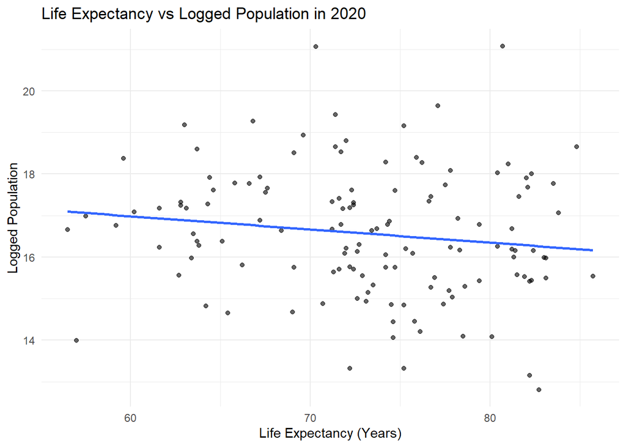

```r
combined |>
  ggplot(mapping = aes(x = life_expectancy, y = log_pop)) +
  geom_point(alpha = 0.6) +
  geom_smooth(method = "lm", formula = y ~ x, se = FALSE) +
  labs(
    title = "Life Expectancy vs Logged Population in 2020",
    x = "Life Expectancy (Years)",
    y = "Logged Population"
  ) +
  theme_minimal()
```

There appears to be a weak negative linear relationship between life expectancy and logged population. The fitted regression line slopes slightly downward, suggesting that countries with higher life expectancy tend to have somewhat smaller populations. However, the points are widely scattered around the line, indicating that the relationship is not particularly strong. Overall, life expectancy may provide some information about population, but it does not appear to be a strong predictor on its own.

### Stats and description

```r
combined |>
  group_by(pop_bins = cut_number(log_pop, n = 4)) |>
  summarise(
    n_countries = n(),
    mean        = mean(life_expectancy),
    median      = median(life_expectancy),
    sd          = sd(life_expectancy),
    min         = min(life_expectancy),
    q1          = quantile(life_expectancy, 0.25),
    q3          = quantile(life_expectancy, 0.75),
    max         = max(life_expectancy),
    .groups     = "drop"
  )
```

```
# A tibble: 4 × 9
  pop_bins    n_countries  mean median    sd   min    q1    q3   max
  <fct>             <int> <dbl>  <dbl> <dbl> <dbl> <dbl> <dbl> <dbl>
1 [12.8,15.5]          33  75.8   76.1  5.96  57    73.2  79.4  85.7
2 (15.5,16.6]          33  73.1   72.7  6.65  61.6  69.1  78.3  83.1
3 (16.6,17.6]          32  70.4   71.8  7.24  56.5  64    74.5  83.8
4 (17.6,21.1]          33  73.0   72    6.87  59.6  67.2  77.8  84.8
```

Mean life expectancy generally decreases as population increases, ranging from approximately 75.76 years in the smallest population group to 70.43 years in the third group. The medians follow a similar pattern, ranging from 76.10 to 71.75 years, before increasing slightly to 72 years in the largest population group. Standard deviations range from approximately 5.96 to 7.24 years, indicating moderate variability within each group. Overall, countries with smaller populations tend to have higher life expectancy, although there is considerable variation across all groups.

## Which variable for logging?

Based on the exploratory data analysis, energy use per person and murder deaths required logarithmic transformations because their original distributions were right-skewed. Logging these variables helped reduce skewness and improve their distributions. Employment rate did not require logging because its distribution did not show substantial skewness. Inflation was not logged because it contains negative values, making a logarithmic transformation inappropriate. Life expectancy also did not require logging because its distribution did not show substantial skewness. Population, the response variable, was already logged during the initial data preparation.

## Logging predictor variables and splitting data

Split your data into an 80/20 training testing split after logging any variables that need logged.

```r
model_data <- combined
set.seed(321)
data_split <- initial_split(model_data, prop = 0.80)

# Create training and testing datasets
train_data <- training(data_split)
test_data <- testing(data_split)

# Check dimensions
dim(train_data)
```

```
[1] 104  14
```

```r
dim(test_data)
```

```
[1] 27 14
```

## Lasso regression

### Making model

Make a lasso regression model for your response vs all predictors on the training data.

```r
# Create recipe
lasso_recipe <- recipe(log_pop ~ ., data = train_data) |>
  update_role(geo, name, year, new_role = "id") |>
  step_dummy(all_nominal_predictors()) |>
  step_normalize(all_numeric_predictors())

# Define LASSO model with the penalty left to tune
lasso_model <- linear_reg(
  penalty = tune(),
  mixture = 1
) |>
  set_engine("glmnet")

# Create workflow
lasso_workflow <- workflow() |>
  add_model(lasso_model) |>
  add_recipe(lasso_recipe)

# Find the penalty with 10 fold cross validation on the training data
set.seed(321)
lasso_folds <- vfold_cv(train_data, v = 10)
lasso_grid <- tibble(penalty = 10^seq(-3, 0.5, length.out = 40))

set.seed(321)
lasso_tuned <- tune_grid(
  lasso_workflow,
  resamples = lasso_folds,
  grid = lasso_grid,
  metrics = metric_set(rmse)
)

best_lasso <- select_best(lasso_tuned, metric = "rmse")
best_lasso
```

```
# A tibble: 1 × 2
  penalty .config
    <dbl> <chr>
1  0.0767 pre0_mod22_post0
```

```r
# Fit model using training data with the best penalty
lasso_fit <- lasso_workflow |>
  finalize_workflow(best_lasso) |>
  fit(data = train_data)

lasso_fit
```

```
══ Workflow [trained] ══════════════════════════════════════════════════════════
Preprocessor: Recipe
Model: linear_reg()

── Preprocessor ────────────────────────────────────────────────────────────────
2 Recipe Steps

• step_dummy()
• step_normalize()

── Model ───────────────────────────────────────────────────────────────────────

Call:  glmnet::glmnet(x = maybe_matrix(x), y = y, family = "gaussian",      alpha = ~1)

   Df  %Dev  Lambda
```

[output cut: 49 more lines]

The penalty is how hard the lasso pushes slopes toward zero, so we try 40 values from 0.001 to about 3 and keep the one with the lowest cross validated RMSE.

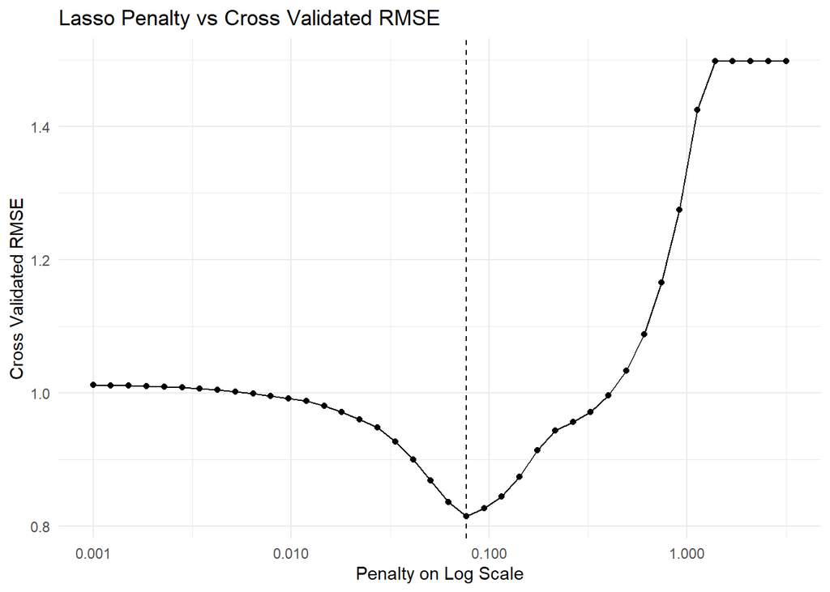

```r
collect_metrics(lasso_tuned) |>
  ggplot(mapping = aes(x = penalty, y = mean)) +
  geom_line() +
  geom_point() +
  geom_vline(xintercept = best_lasso$penalty, linetype = "dashed") +
  scale_x_log10() +
  labs(title = "Lasso Penalty vs Cross Validated RMSE",
       x = "Penalty on Log Scale", y = "Cross Validated RMSE") +
  theme_minimal()
```

The cross validated RMSE is lowest at a penalty of about 0.077, which is the dashed line, with an RMSE of about 0.82. It gets much worse when the penalty is tiny since the model keeps too many noisy variables, and when it’s big since every slope shrinks to zero. This replaces the penalty of 0.1 that we picked by hand before.

### Which variables

By looking at the slopes, which variables should be considered included in the model

```r
# Extract coefficients
lasso_coefs <- coef(
  extract_fit_engine(lasso_fit),
  s = best_lasso$penalty
)

# Display all coefficients
as.matrix(lasso_coefs)
```

```
                                 s=0.07666822
(Intercept)                       16.59854249
children_per_woman                 0.00000000
sanitation_access_pct              0.00000000
employment_rate_pct                0.00000000
inflation_pct                     -0.07418439
life_expectancy                    0.39271176
log_people_in_poverty              0.31594347
log_murder_deaths                  1.16623781
log_energy_use                     0.05954229
income_level_Low.income            0.00000000
income_level_Lower.middle.income   0.00000000
income_level_Upper.middle.income  -0.13871362
Democracy_Yes                      0.00000000
```

```r
# Identify variables with nonzero slopes
included_vars <- rownames(lasso_coefs)[
  as.vector(lasso_coefs != 0)
]

# Exclude intercept
setdiff(included_vars, "(Intercept)")
```

```
[1] "inflation_pct"                    "life_expectancy"
[3] "log_people_in_poverty"            "log_murder_deaths"
[5] "log_energy_use"                   "income_level_Upper.middle.income"
```

Based on the LASSO regression coefficients at the best penalty of about 0.077, six predictors were retained in the model because their slopes were nonzero. These variables were inflation, life expectancy, logged people in poverty, logged murder deaths, logged energy use, and upper-middle-income level. The remaining predictors had coefficients of zero and were excluded from the model. LASSO therefore reduced the number of predictors by shrinking less influential coefficients to zero.

### Model evaluation-regression metrics on testing.

```r
# Get predictions on testing data
lasso_test_predictions <- predict(
  lasso_fit,
  new_data = test_data
) |>
  pull(.pred)

# Calculate MSE, RMSE, and MAE
lasso_test_mse <- mean(
  (test_data$log_pop - lasso_test_predictions)^2
)

lasso_test_rmse <- sqrt(lasso_test_mse)

lasso_test_mae <- mean(
  abs(test_data$log_pop - lasso_test_predictions)
)

# Display results
tibble(
  MSE = lasso_test_mse,
  RMSE = lasso_test_rmse,
  MAE = lasso_test_mae
)
```

```
# A tibble: 1 × 3
    MSE  RMSE   MAE
  <dbl> <dbl> <dbl>
1 0.530 0.728 0.562
```

The LASSO model achieved a testing MSE of 0.5299, RMSE of 0.7279, and MAE of 0.5616. These metrics measure the prediction errors when estimating logged population for observations not used during model training. The RMSE indicates that the model’s predictions differ from actual logged population values by approximately 0.73 units on average, with larger errors receiving more weight. Overall, these metrics provide a baseline for comparing LASSO with the other regression models.

## Regression Tree

### Making model

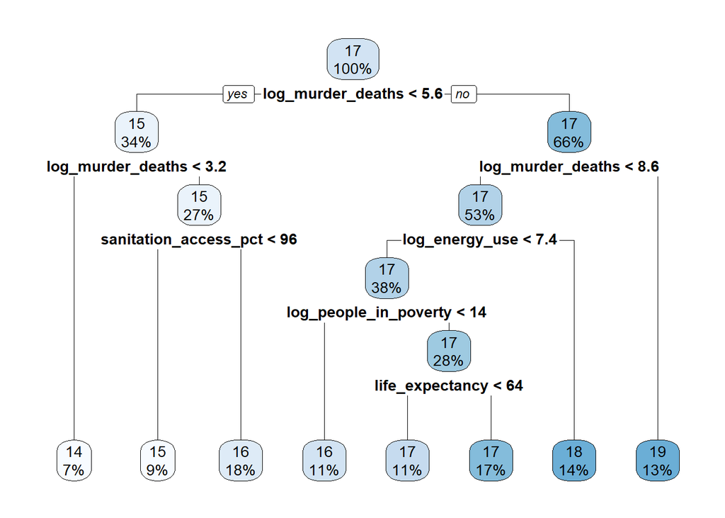

```r
set.seed(321)
population_recipe=recipe(log_pop~., data=train_data) |>
  update_role(geo, name, year, new_role = "id")
tree_spec <- decision_tree() |>
  set_mode("regression")|>
  set_engine("rpart", model=TRUE)

tree_workflow <- workflow() |>
  add_recipe(population_recipe) |>
  add_model(tree_spec)

population_tree=tree_workflow |>
  fit(data = train_data)

tree_object=population_tree |>
  extract_fit_engine()

rpart.plot(tree_object)
```

### Which variables

From looking at the plot, we can see that Murder Deaths, Sanitation Access Percent, Energy Use, People in Poverty, and Life Expectancy should be considered when making our model.

### Model evaluation-regression metrics on testing.

```r
regression_metrics <- metric_set(mse, rmse, mae)

# predictions from the tree fit on the training data
test_results <- augment(population_tree, new_data = test_data) ## adding original data
train_results <- augment(population_tree, new_data = train_data)

test_results |>
  regression_metrics(truth = log_pop, estimate = .pred)
```

```
# A tibble: 3 × 3
  .metric .estimator .estimate
  <chr>   <chr>          <dbl>
1 mse     standard       0.850
2 rmse    standard       0.922
3 mae     standard       0.695
```

```r
train_results |>
  regression_metrics(truth = log_pop, estimate = .pred)
```

```
# A tibble: 3 × 3
  .metric .estimator .estimate
  <chr>   <chr>          <dbl>
1 mse     standard       0.531
2 rmse    standard       0.729
3 mae     standard       0.558
```

The Regression Decision Tree model achieved a testing MSE of 0.85, RMSE of 0.92, and MAE of 0.70. These metrics measure the prediction errors when estimating logged population for observations in the testing set. The training RMSE is 0.73 and the testing RMSE is 0.92, so the tree fits the countries it was trained on better than new ones, which is some overfitting. We can use these metrics to compare against the performance of other regression models.

## Random forest

### Making model

Make a random forest model for your response vs all predictors on the training data.

A random forest has settings we can’t know ahead of time, so we tune the number of variables tried at each split, `mtry`, and the smallest node size, `min_n`, with 10 fold cross validation on the training data. We use 500 trees and try 15 combinations, then pick the one with the lowest cross validated RMSE.

```r
rf_recipe <- recipe(log_pop ~ ., data = train_data) |>
  update_role(geo, name, year, new_role = "id") |>
  step_string2factor(all_nominal_predictors())

rf_tune_spec <- rand_forest(mtry = tune(), min_n = tune(), trees = 500) |>
  set_engine("ranger") |>
  set_mode("regression")

rf_tune_workflow <- workflow() |>
  add_recipe(rf_recipe) |>
  add_model(rf_tune_spec)

set.seed(321)
rf_folds <- vfold_cv(train_data, v = 10)
rf_grid <- expand_grid(mtry = c(2, 4, 6, 8, 10), min_n = c(2, 5, 10))

set.seed(321)
rf_tuned <- tune_grid(
  rf_tune_workflow,
  resamples = rf_folds,
  grid = rf_grid,
  metrics = metric_set(rmse)
)

show_best(rf_tuned, metric = "rmse", n = 5)
```

```
# A tibble: 5 × 8
   mtry min_n .metric .estimator  mean     n std_err .config
  <dbl> <dbl> <chr>   <chr>      <dbl> <int>   <dbl> <chr>
1     8     2 rmse    standard   0.877    10  0.0615 pre0_mod10_post0
2     6     2 rmse    standard   0.878    10  0.0606 pre0_mod07_post0
3     8     5 rmse    standard   0.883    10  0.0625 pre0_mod11_post0
4     6     5 rmse    standard   0.884    10  0.0617 pre0_mod08_post0
5     8    10 rmse    standard   0.886    10  0.0619 pre0_mod12_post0
```

```r
best_rf <- select_best(rf_tuned, metric = "rmse")
best_rf
```

```
# A tibble: 1 × 3
   mtry min_n .config
  <dbl> <dbl> <chr>
1     8     2 pre0_mod10_post0
```

The best settings are `mtry` = 8 and `min_n` = 2 with a cross validated RMSE of about 0.88, but the next few combinations are almost the same so the settings don’t matter much here. We refit that forest on all of the training data and turn on permutation importance, which measures how much the error goes up when a variable is shuffled.

```r
rf_final_spec <- rand_forest(mtry = best_rf$mtry, min_n = best_rf$min_n, trees = 500) |>
  set_engine("ranger", importance = "permutation") |>
  set_mode("regression")

set.seed(321)
rf_fit <- workflow() |>
  add_recipe(rf_recipe) |>
  add_model(rf_final_spec) |>
  fit(data = train_data)
```

### Which variables

By looking at the variable importance plot, which variables should be considered included in the model

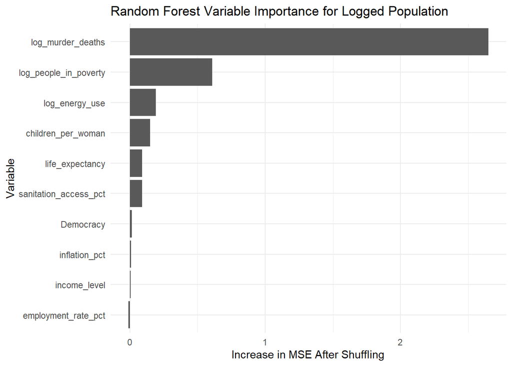

```r
rf_importance <- tibble(
  variable   = names(extract_fit_engine(rf_fit)$variable.importance),
  importance = extract_fit_engine(rf_fit)$variable.importance
)

rf_importance |>
  ggplot(mapping = aes(x = importance, y = reorder(variable, importance))) +
  geom_col() +
  labs(title = "Random Forest Variable Importance for Logged Population",
       x = "Increase in MSE After Shuffling", y = "Variable") +
  theme_minimal()
```

Logged murder deaths is by far the most important variable, with an increase in MSE of about 2.65 when it’s shuffled, and logged people in poverty is a clear second at about 0.61. Logged energy use and children per woman are a distant third and fourth at about 0.19 and 0.15, and everything else is below 0.1, with employment rate slightly negative which means shuffling it didn’t hurt the predictions at all. We would include murder deaths and people in poverty for sure, and energy use and children per woman are borderline.

### Model evaluation-regression metrics on testing.

```r
rf_metrics <- metric_set(mse, rmse, mae)

rf_test_metrics <- augment(rf_fit, new_data = test_data) |>
  rf_metrics(truth = log_pop, estimate = .pred)

rf_train_metrics <- augment(rf_fit, new_data = train_data) |>
  rf_metrics(truth = log_pop, estimate = .pred)

# training and testing side by side
bind_rows(Training = rf_train_metrics, Testing = rf_test_metrics, .id = "data") |>
  select(data, .metric, .estimate) |>
  pivot_wider(names_from = .metric, values_from = .estimate)
```

```
# A tibble: 2 × 4
  data       mse  rmse   mae
  <chr>    <dbl> <dbl> <dbl>
1 Training 0.113 0.337 0.259
2 Testing  0.644 0.802 0.554
```

```r
# out of bag error, which uses rows each tree did not see
rf_oob_mse <- extract_fit_engine(rf_fit)$prediction.error
tibble(oob_mse = rf_oob_mse, oob_rmse = sqrt(rf_oob_mse))
```

```
# A tibble: 1 × 2
  oob_mse oob_rmse
    <dbl>    <dbl>
1   0.801    0.895
```

The random forest achieved a testing MSE of 0.64, RMSE of 0.80, and MAE of 0.55. The training RMSE of 0.34 is way lower, but that’s expected for a forest since every tree was trained on most of the training rows, so we don’t use it to check overfitting. The out of bag RMSE is 0.89 and the cross validated RMSE is 0.88, which are both a little higher than the testing RMSE, so the testing result isn’t too good to be true and the model generalizes about as well as those two estimates say. The testing set is only 27 countries so these numbers move around a bit.

## Variable slection comparison

What were the similarities and the difference between the variables selected for each model.

For the lasso we count any variable with a slope that isn’t zero, for the tree any variable that shows up in a split, and for the forest we show the importance from the plot.

```r
# lasso, with the dummy columns matched back to the original variable
lasso_slopes <- as.matrix(coef(extract_fit_engine(lasso_fit), s = best_lasso$penalty))
lasso_selected <- rownames(lasso_slopes)[lasso_slopes[, 1] != 0] |>
  str_replace("^income_level_.*", "income_level") |>
  str_replace("^Democracy_.*", "Democracy") |>
  unique()

# tree, every variable used in a split
tree_selected <- unique(as.character(tree_object$frame$var))
tree_selected <- tree_selected[tree_selected != "<leaf>"]

rf_importance |>
  arrange(desc(importance)) |>
  mutate(
    lasso = if_else(variable %in% lasso_selected, "Yes", "No"),
    tree  = if_else(variable %in% tree_selected, "Yes", "No")
  ) |>
  select(variable, lasso, tree, forest_importance = importance) |>
  knitr::kable(digits = 3, caption = "Which variables each model selected")
```

Which variables each model selected

| variable | lasso | tree | forest_importance |
| --- | --- | --- | --- |
| log_murder_deaths | Yes | Yes | 2.648 |
| log_people_in_poverty | Yes | Yes | 0.607 |
| log_energy_use | Yes | Yes | 0.193 |
| children_per_woman | No | No | 0.150 |
| life_expectancy | Yes | Yes | 0.090 |
| sanitation_access_pct | No | Yes | 0.090 |
| Democracy | No | No | 0.015 |
| inflation_pct | Yes | No | 0.008 |
| income_level | Yes | No | 0.007 |
| employment_rate_pct | No | No | -0.011 |

All three models pick logged murder deaths as the main variable, since it has by far the biggest slope in the lasso, it’s the first split in the tree, and it’s the top bar in the forest. Logged people in poverty and logged energy use are also in all three, and life expectancy is in the lasso and the tree but the forest only gives it an importance of 0.09. The differences are that the lasso is the only one that keeps inflation and the upper middle income level, which have almost no importance in the forest, that the tree is the only one that uses sanitation access, and that the forest is the only one that gives children per woman any real importance at 0.15, so it’s the one variable the lasso and the tree both skip that the forest likes. Employment rate is left out by all three, which fits what we saw in the exploratory analysis where it had no relationship with population.

## Best model

Which model would you reccomend your team use? Why? Are there tradeoff between interpretability and model metrics?

```r
# one row per model, testing metrics on the same 27 countries
wide_metrics <- function(m, name) {
  m |>
    select(.metric, .estimate) |>
    pivot_wider(names_from = .metric, values_from = .estimate) |>
    mutate(model = name, .before = 1)
}

bind_rows(
  tibble(model = "Lasso", mse = lasso_test_mse, rmse = lasso_test_rmse, mae = lasso_test_mae),
  wide_metrics(test_results |> regression_metrics(truth = log_pop, estimate = .pred), "Regression tree"),
  wide_metrics(rf_test_metrics, "Random forest")
) |>
  knitr::kable(digits = 3, caption = "Testing metrics for each model")
```

Testing metrics for each model

| model | mse | rmse | mae |
| --- | --- | --- | --- |
| Lasso | 0.530 | 0.728 | 0.562 |
| Regression tree | 0.850 | 0.922 | 0.695 |
| Random forest | 0.644 | 0.802 | 0.554 |

We would recommend the lasso model. It has the lowest MSE and RMSE on the testing set at 0.53 and 0.73, ahead of the random forest at 0.64 and 0.80 and the regression tree at 0.85 and 0.92, and the random forest only edges it out on MAE with 0.55 against 0.56. The lasso penalty was found with cross validation so the comparison is fair, and the lasso is a short equation that we can read and explain while the forest is a black box, so there’s no reason to give up the lasso for a model that isn’t better. The tradeoff is that the forest can pick up curves and interactions that the lasso can’t, but here that didn’t show up as lower error on the testing countries. The tree is the easiest to explain but it has the worst error on every metric and it overfits, with a training RMSE of 0.73 against a testing RMSE of 0.92. All three models agree that logged murder deaths is the most important predictor of logged population, and the testing set is only 27 countries so the gap between the lasso and the forest could change with a different split.

## Your question

You will write your own question about the data, create a data visualization that can help answer your question, and write an answer to your question. The question/visualization should explore the relationship between at least 2 of the variables in the dataset. Be sure you include both the question and the answer to your question based on the visualization you have created. It should be a different question than last two mini-projects.

Do democracies really have lower murder rates than other countries, or is that just because democracies tend to be richer?

Murder deaths is a total so it mostly depends on how big a country is, which means we turn it into a murder rate per 100,000 people using the population. The graph splits the countries by income level, with each dot a country and the black line the median.

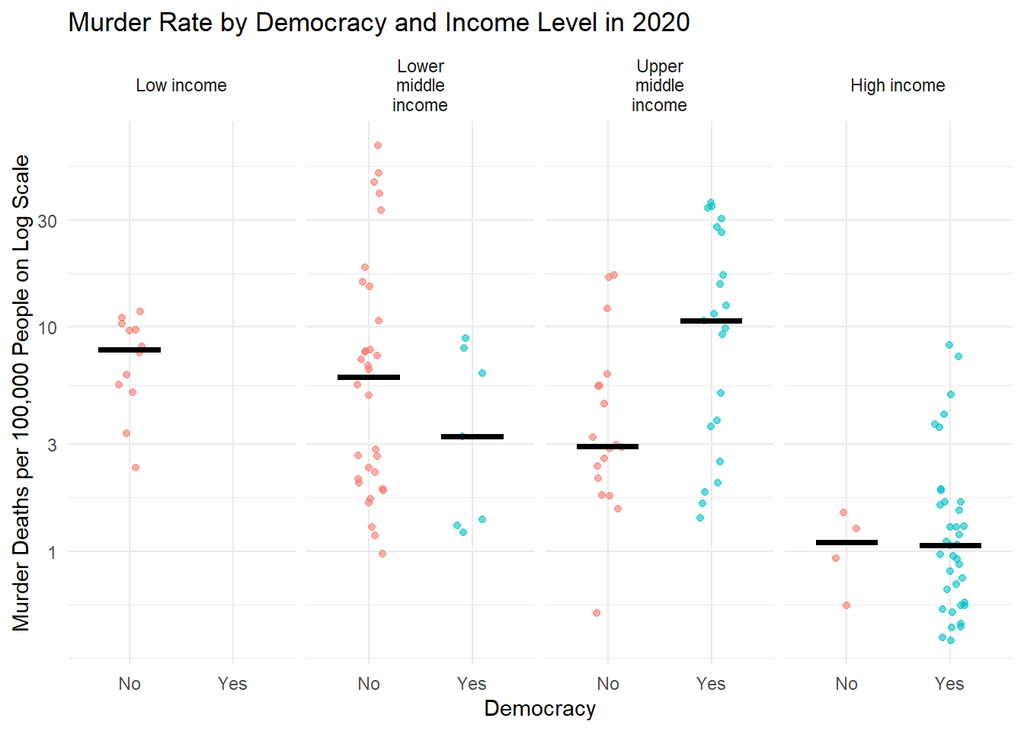

```r
income_order <- c("Low income", "Lower middle income", "Upper middle income", "High income")

rate_data <- combined |>
  mutate(
    murder_per_100k = exp(log_murder_deaths - log_pop) * 100000,
    income_level    = factor(income_level, levels = income_order)
  )

rate_medians <- rate_data |>
  group_by(income_level, Democracy) |>
  summarise(median = median(murder_per_100k), .groups = "drop")

rate_data |>
  ggplot(mapping = aes(x = Democracy, y = murder_per_100k, color = Democracy)) +
  geom_jitter(width = 0.15, alpha = 0.6) +
  geom_crossbar(
    data = rate_medians,
    mapping = aes(x = Democracy, y = median, ymin = median, ymax = median),
    width = 0.6, color = "black", inherit.aes = FALSE
  ) +
  scale_y_log10() +
  facet_wrap(~ income_level, nrow = 1, labeller = label_wrap_gen(width = 12)) +
  labs(title = "Murder Rate by Democracy and Income Level in 2020",
       x = "Democracy", y = "Murder Deaths per 100,000 People on Log Scale") +
  theme_minimal() +
  theme(legend.position = "none")
```

```r
rate_data |>
  group_by(Democracy) |>
  summarise(
    n_countries = n(),
    median      = median(murder_per_100k),
    q1          = quantile(murder_per_100k, 0.25),
    q3          = quantile(murder_per_100k, 0.75),
    .groups     = "drop"
  )
```

```
# A tibble: 2 × 5
  Democracy n_countries median    q1    q3
  <chr>           <int>  <dbl> <dbl> <dbl>
1 No                 66   5.02 2.10   9.29
2 Yes                65   1.66 0.953  7.37
```

```r
rate_data |>
  group_by(income_level, Democracy) |>
  summarise(n_countries = n(), median = median(murder_per_100k), .groups = "drop")
```

```
# A tibble: 7 × 4
  income_level        Democracy n_countries median
  <fct>               <chr>           <int>  <dbl>
1 Low income          No                 12   7.93
2 Lower middle income No                 32   5.98
3 Lower middle income Yes                 7   3.24
4 Upper middle income No                 18   2.94
5 Upper middle income Yes                21  10.7
6 High income         No                  4   1.10
7 High income         Yes                37   1.06
```

```r
# share of countries that aren't democracies with a rate above the median democracy
democracy_median <- median(rate_data$murder_per_100k[rate_data$Democracy == "Yes"])
mean(rate_data$murder_per_100k[rate_data$Democracy == "No"] > democracy_median)
```

```
[1] 0.8484848
```

Overall democracies do have lower murder rates, with a median of 1.66 deaths per 100,000 people against 5.02 for countries that aren’t democracies, and about 85% of the countries that aren’t democracies are above the median democracy. Most of that gap goes away once we split by income level though. Almost all of the high income countries are democracies, 37 out of 41, and their median is about 1.06 either way, with 1.06 for the democracies against 1.10 for the 4 that aren’t. In the upper middle income group the democracies actually have the higher median, 10.7 against 2.94, and in the lower middle income group they’re lower, 3.24 against 5.98, but there are only 7 democracies there, and there are no low income democracies at all. So democracy on its own doesn’t explain murder rates much, and most of the gap in the first numbers comes from democracies being richer, since income level separates the countries better with a median of 1.06 for high income against 7.93 for low income.